# What Makes A Student Drinks?

Jingjing Tu

# Introduction

Alcohol is an often abused substance that troubles many adults as they struggle to cope with emotional and physical stress that comes with the stress from life. However, sometime we may overlook the effect of this substance had on the younger generation which tends to be more impressionable. As a relatively care-free generation, what lead them to such a intoxicating substance?

To fill the gap on this area, researcher in Portugal conducted a survey to collect data on students’ alcohol consumption and their demographic information and other data that highly related to their emotional and physical status. The dataset have 1044 instances and it was collected from the locations such as Gabriel Pereira and Mousinho da Silveira. The datasets have a total of 33 attribute columns of which we could do some column selection based on certain parameters.

To have a clearer picture of the whole dataset, I have create a dashboard with some visualization of the key features of the dataset. [EDA Dashboard](https://jojojojojojo44.github.io/final_project/)

## Alcohol Consumption Trend at different Age

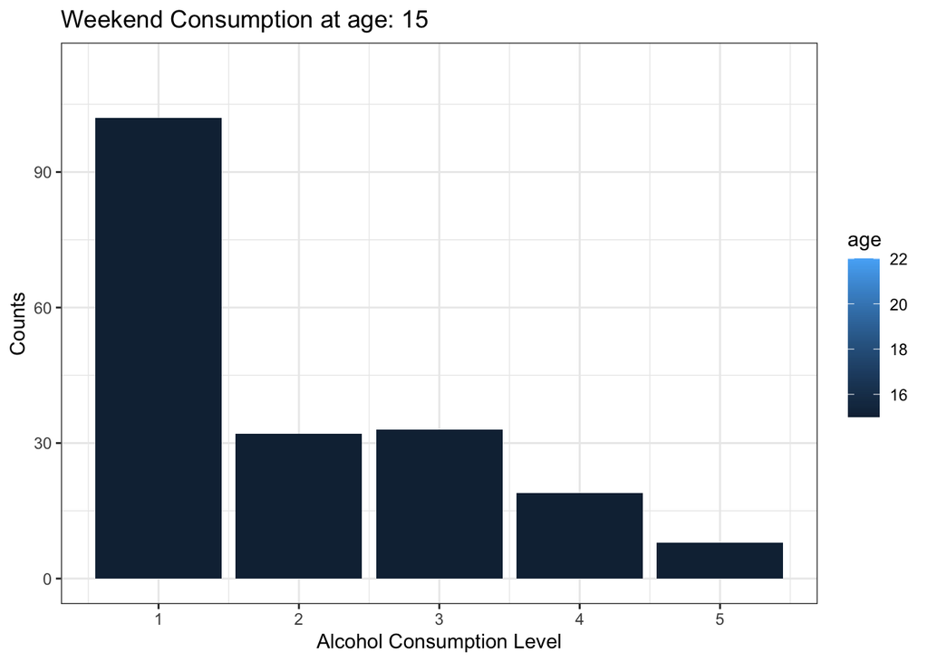

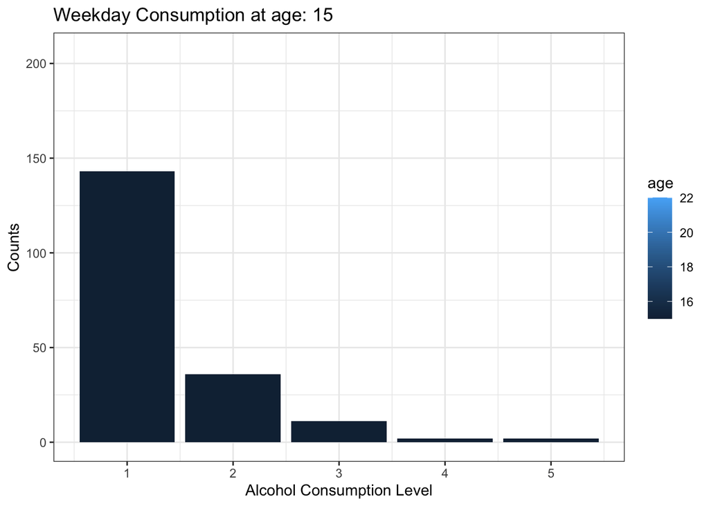

# Regression Analysis On The Alcohol Consumption Level

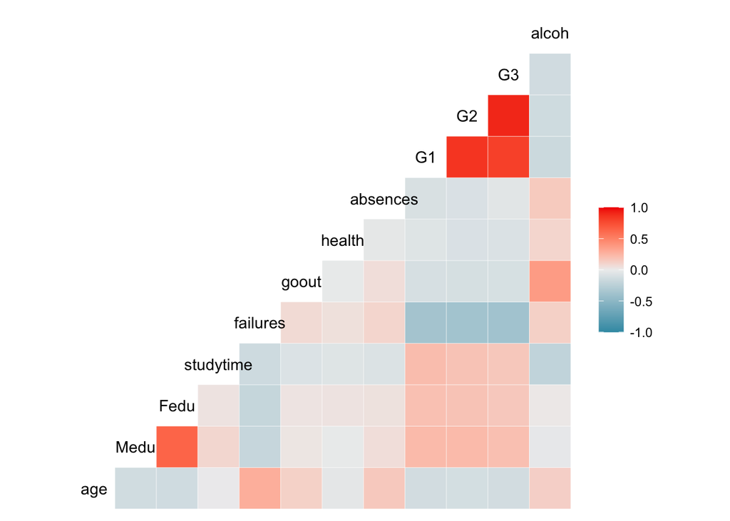

The above correlation plot shows that alcohol consumption has relatively strong positive correlations with going out, absences and the number of failed classes. And it has relatively strong negative correlations with the time students spend on study and their grade.

To get a clearer picture of how those factors affect the alcohol consumption level, a regression on the alcohol consumption level is needed.

```
## # A tibble: 12 x 5
##    term        estimate std.error statistic  p.value
##    <chr>          <dbl>     <dbl>     <dbl>    <dbl>
##  1 (Intercept)   1.95      0.372      5.23  2.01e- 7
##  2 sex1          1.07      0.115      9.32  6.63e-20
##  3 Pstatus1      0.0926    0.168      0.553 5.81e- 1
##  4 Medu         -0.0884    0.0633    -1.40  1.62e- 1
##  5 Fedu          0.0633    0.0639     0.992 3.22e- 1
##  6 G3           -0.0254    0.0154    -1.65  9.92e- 2
##  7 failures      0.109     0.0897     1.22  2.23e- 1
##  8 goout         0.589     0.0468    12.6   6.08e-34
##  9 studytime    -0.268     0.0675    -3.97  7.59e- 5
## 10 schoolsup1   -0.112     0.172     -0.654 5.13e- 1
## 11 romantic1     0.145     0.114      1.27  2.03e- 1
## 12 health        0.0715    0.0380     1.88  6.01e- 2
```

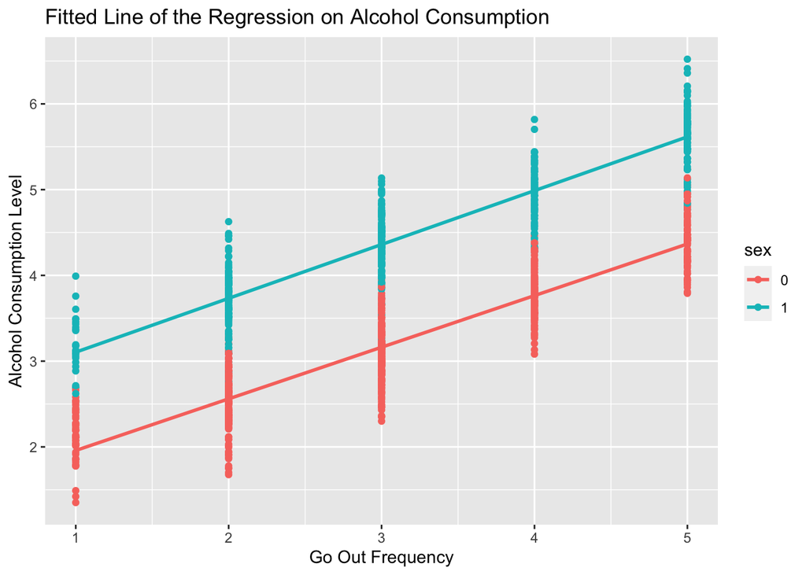

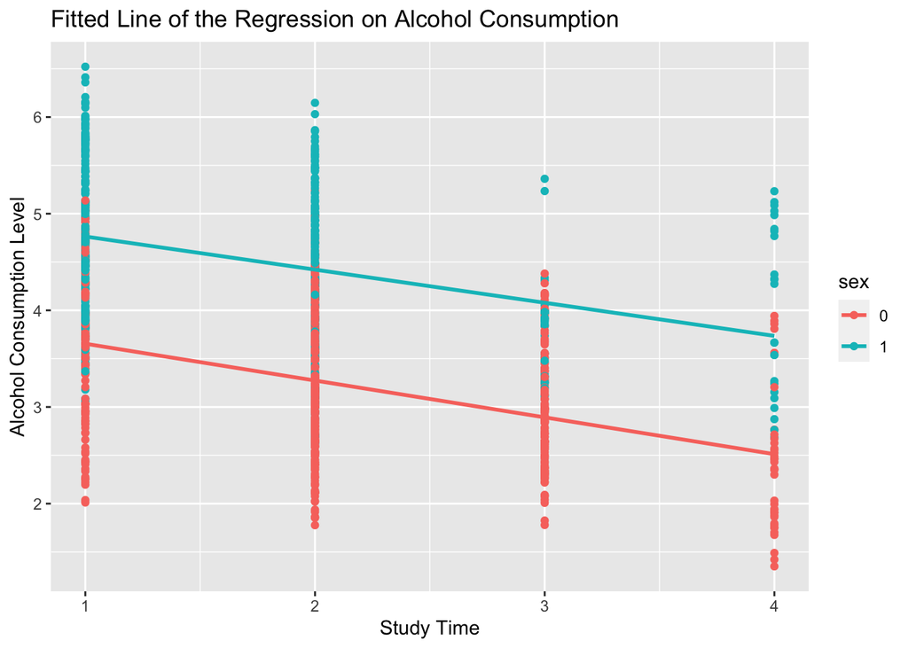

The regression model we built used alcohol consumption level as the dependent variable, sex, parent’s cohabitation status, parent’s education level, final grade, the number of failed classes, how often students go out, whether have extra educational support, whether in a romantic relationship and student’s health status as the independent variable. As we could see fromt the regression results above, there are only three independent variables which are statistically significant, sex, how devoted the students are towards study(studytime), and how often students go out(goout). As we could see from the plots above, male students tend to have a higher level of alcohol consumption on average compared to female student. How often the student goes out has a positive effect on the alcohol consumption and how devoted the students are towards study has a negative effect on the alcohol consumption.

## Why those factors matter?

We then ask, why does those factors matter instead of those factors relate more to their emotional and physical status?

One possible explanation is that alcohol has different function to high school students compared to adults. The alcohol represents for party and fun time for a 16-year-old which could be supported by the positive relation between alcohol consumption and how often students go out and the negative relation between alcohol consumption and study time.

Although the regression result support such an explanation on some level, the data is collected from a specific area and the representative power of the dataset was weaken due to the limitation of the dataset. As we could see from the EDA of the dataset, most of the students in the dataset come from a functional family with educated parents. With a functional family like that, there is little need for students to turn to alcohol for escape from the reality.

# Will Alcohol Consumption Level Affect Academic Performance?

```
## # A tibble: 7 x 5
##   term        estimate std.error statistic  p.value
##   <chr>          <dbl>     <dbl>     <dbl>    <dbl>
## 1 (Intercept)    9.56     0.493      19.4  7.57e-72
## 2 alcoh         -0.212    0.0590     -3.60 3.34e- 4
## 3 studytime      0.620    0.141       4.39 1.26e- 5
## 4 schoolsup1    -1.28     0.363      -3.52 4.52e- 4
## 5 romantic1     -0.872    0.240      -3.63 2.92e- 4
## 6 Medu           0.490    0.133       3.68 2.46e- 4
## 7 Fedu           0.225    0.136       1.66 9.77e- 2
```

[figure not shown]

As for whether the alcohol consumption level will affect students’ academic performance, we could conclude from the regression result above that it has a negative effect on their academic performance when we control for their study time, whether receiving additional educational support, whether was in a romantic relationship and parents’ education.

# Conclusion

High alcohol consumption level is related to sex, study time and how often students go out. And alcohol consumption level has a negative effect on students’ academic performance. For a better academic performance, school and parents could consider limit the time students spend with their peer. But for a more convincing conclusion on what factors contribute to high alcohol consumption level, additional and more representative data on student alcohol consumption is needed.

## Data

[Student Alcohol Consumption Dataset](https://www.kaggle.com/uciml/student-alcohol-consumption): The data used in this project is collected by Paulo Cortez and updated by UCI Machine Learning.

## Coding Reference

[The Plotly](https://plotly.com/r/): For creating plots

[The R Graph Gallery](https://www.r-graph-gallery.com/index.html): For creating plots

[Flexdashboard for R](https://rmarkdown.rstudio.com/flexdashboard/index.html): For creating dashboard

[Github Page](https://pages.github.com/): For creating web accessible content

*This page was created for the final project of Data Visualization for Data Science course at McCourt School of Public Policy, Georgetown University, taught by Professor Taylor Corbett.*

*Thanks to Professor Corbett for teaching me this semester and for the feedback on this project.*